# Multiple Regression

Deviprasad Saka

2024-04-13

```r
file_path <- "D:/Multivariate Analysis/Assignment-7/Ship_data.csv"
mydata <- read.csv(file_path)
autompg <- read.csv("D:/Multivariate Analysis/Assignment-7/Ship_data.csv")
str(mydata)
```

```
## 'data.frame':    99 obs. of  11 variables:
##  $ Hs      : num  2.24 2.26 2.29 2.33 2.37 ...
##  $ Power   : num  16531 16551 16604 16669 16739 ...
##  $ Tp      : num  13 13.1 13.1 13 13 ...
##  $ V       : num  10.52 9.64 11.25 11.31 9.27 ...
##  $ dist    : num  25.6 49.9 99.9 149.8 199.8 ...
##  $ hours   : num  2.3 2.45 2.34 2.34 2.06 ...
##  $ n       : num  2.09 2.09 2.1 2.1 2.1 ...
##  $ t       : num  0.203 0.209 0.212 0.213 0.208 ...
##  $ tot_r   : num  1102 1103 1106 1110 1113 ...
##  $ w       : num  0.219 0.259 0.268 0.237 0.222 ...
##  $ wave_dir: num  171 172 173 175 177 ...
```

Q1.Model Development

```r
# Performing multiple regression on the dataset
# Fit a linear regression model
fit <- lm(Power ~ V + n + tot_r + t + w, data = mydata)
#show the results
summary(fit)
```

```
##
## Call:
## lm(formula = Power ~ V + n + tot_r + t + w, data = mydata)
##
## Residuals:
##     Min      1Q  Median      3Q     Max
## -26.605 -10.886   4.629   9.776  19.922
##
## Coefficients:
##               Estimate Std. Error t value Pr(>|t|)
## (Intercept)  3.549e+04  1.753e+03  20.246   <2e-16 ***
## V            1.209e+00  2.246e+00   0.538    0.592
## n           -2.649e+04  1.156e+03 -22.918   <2e-16 ***
## tot_r        3.312e+01  6.061e-01  54.636   <2e-16 ***
## t           -1.634e+01  2.539e+02  -0.064    0.949
## w           -4.299e+00  7.646e+01  -0.056    0.955
## ---
## Signif. codes:  0 '***' 0.001 '**' 0.01 '*' 0.05 '.' 0.1 ' ' 1
##
## Residual standard error: 14.33 on 93 degrees of freedom
## Multiple R-squared:      1,  Adjusted R-squared:      1
## F-statistic: 5.336e+05 on 5 and 93 DF,  p-value: < 2.2e-16
```

This summary provides the results of a multiple linear regression model where the response variable is “Power” and the predictor variables are “V,” “n,” “tot_r,” “t,” and “w.”. Overall, the model seems to have very high explanatory power, with an adjusted R-squared of 1, indicating that all variability in the “Power” variable is explained by the predictors. However, it’s important to interpret the coefficients carefully, considering the significance levels and the practical implications of each predictor.

In this step, we loaded the ship_data and fitted a multiple regression model using the lm() function. The model predicts the power based on several predictor variables: Ship speed(V), Propeller rps(n), Total resistance (tot_r), Thrust deduction fraction (t) and wake fraction (w).

```r
coefficients(fit)
```

```
##   (Intercept)             V             n         tot_r             t
##  35493.005902      1.208804 -26492.201743     33.115861    -16.340305
##             w
##     -4.299125
```

These are the estimated coefficients for each predictor variable in the multiple linear regression model:

Intercept: The estimated intercept of the regression line is approximately 35493.006.

V: The estimated coefficient for the predictor variable “V” is approximately 1.209.

n: The estimated coefficient for the predictor variable “n” is approximately -26492.202.

tot_r: The estimated coefficient for the predictor variable “tot_r” is approximately 33.116.

t: The estimated coefficient for the predictor variable “t” is approximately -16.340.

w: The estimated coefficient for the predictor variable “w” is approximately -4.299.

These coefficients represent the change in the response variable “Power” for each unit increase in the corresponding predictor variable, holding all other variables constant. For example, for each unit increase in “V,” the estimated change in “Power” is approximately 1.209, and so on for the other variables.

```r
confint(fit,level=0.95)
```

```
##                     2.5 %        97.5 %
## (Intercept)  32011.717441  38974.294364
## V               -3.251592      5.669201
## n           -28787.725273 -24196.678213
## tot_r           31.912227     34.319495
## t             -520.447188    487.766577
## w             -156.138502    147.540253
```

The 95% confidence intervals indicate the range of plausible values for each coefficient estimate in the multiple linear regression model. For instance, we are 95% confident that the true population coefficient for “n” falls within the range of approximately -28787.725 to -24196.678, based on the sample data.

```r
fitted(fit)
```

```
##        1        2        3        4        5        6        7        8
## 16511.50 16530.77 16587.02 16653.44 16721.47 16777.91 16842.38 16933.12
##        9       10       11       12       13       14       15       16
## 16999.77 17061.40 17116.22 17160.09 17202.15 17255.57 17316.93 17426.28
##       17       18       19       20       21       22       23       24
## 17574.21 17743.04 17923.77 18128.68 18360.38 18585.92 18893.16 19202.31
##       25       26       27       28       29       30       31       32
## 19489.01 19787.74 20084.14 20282.88 20488.65 20696.11 20824.06 20896.84
##       33       34       35       36       37       38       39       40
## 21001.84 21211.57 21348.53 21408.43 21486.33 21616.46 21761.32 21931.34
##       41       42       43       44       45       46       47       48
## 22181.00 22442.15 22674.88 22787.26 22804.49 22766.42 22714.04 22616.67
##       49       50       51       52       53       54       55       56
## 22537.63 22479.55 22443.93 22436.72 22429.01 22438.59 22499.20 22621.72
##       57       58       59       60       61       62       63       64
## 22737.95 22829.66 22884.53 22887.63 22835.17 22647.60 22395.59 22127.85
##       65       66       67       68       69       70       71       72
## 21920.58 21783.81 21688.35 21569.22 21428.18 21291.26 21126.13 20930.44
##       73       74       75       76       77       78       79       80
## 20735.71 20572.04 20402.82 20228.62 20051.35 19895.81 19751.21 19630.83
##       81       82       83       84       85       86       87       88
## 19534.64 19452.72 19364.19 19228.04 19087.96 18923.96 18715.65 18474.76
##       89       90       91       92       93       94       95       96
## 18167.12 17889.53 17622.94 17345.06 17090.17 16901.62 14942.74 14940.65
##       97       98       99
## 14940.51 14937.75 14934.09
```

Q3.Residual Analysis

```r
library(GGally)
```

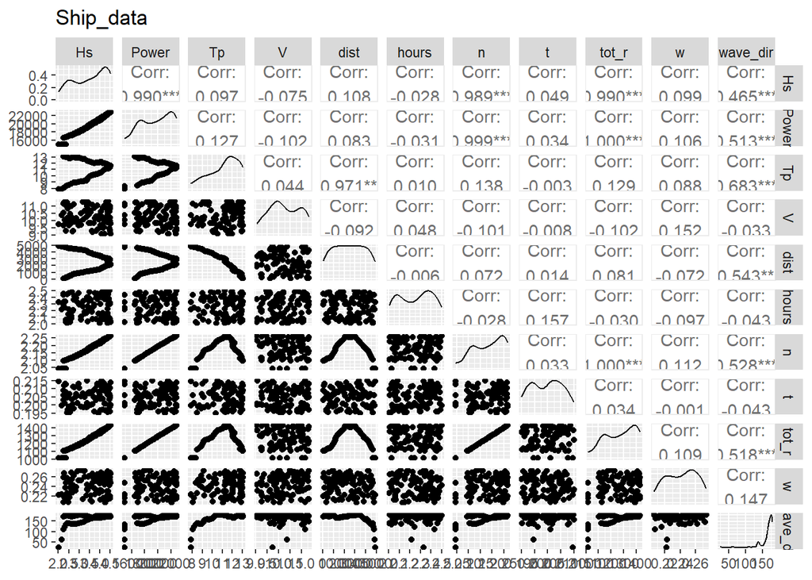

```r
ggpairs(data=mydata, title="Ship_data")
```

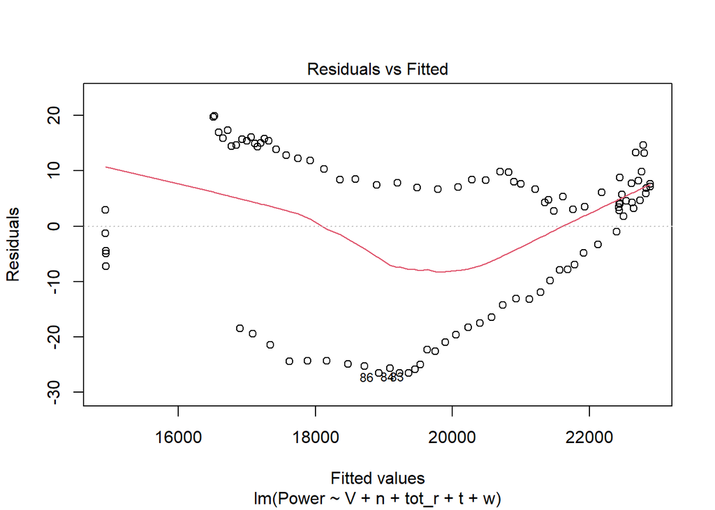

```r
plot(fit, which=1) # Residuals vs Fitted
```

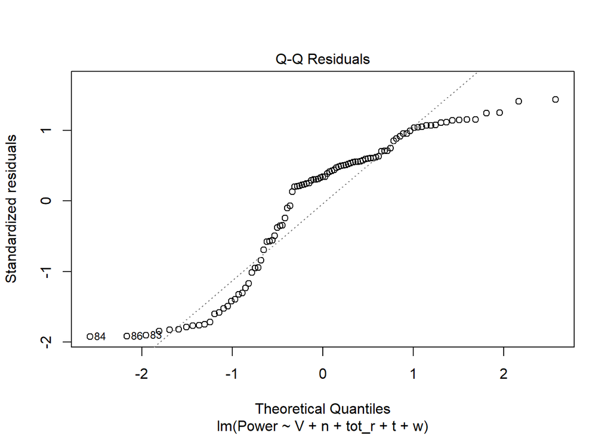

```r
plot(fit, which=2) # Normal Q-Q plot
```

This is a Residuals vs Fitted plot, which is commonly used in regression analysis to assess the goodness of fit of a regression model. The main components of the graph are as follows:

Vertical Axis (Y-axis): This represents the residuals, which are the differences between the observed values and the fitted values from the model. The residuals range from about -30 to 20.

Points on the Graph: Each point represents an observation from the dataset. The position of the point is determined by its fitted value and its residual.

Smooth Red Line: This line is a smooth curve that helps to visualize the trend in the residuals. It appears to show a non-linear pattern, suggesting that the relationship between the predictors and the response variable may not be perfectly linear.

Equation on the X-axis: The equation “lm(Power ~ V + n + tot_r + t + w)” suggests that the linear model (lm) has been fitted using ‘Power’ as the response variable and ‘V’, ‘n’, ‘tot_r’, ‘t’, and ‘w’ as predictor variables.

From the pattern of the points and the red line, it looks like there may be some non-linearity in the relationship between the predictors and the response variable, or there might be other issues such as heteroscedasticity (non-constant variance of residuals) or outliers affecting the model’s performance. Ideally, for a well-fitted linear regression model, the residuals should be randomly scattered around the horizontal axis (zero), with no discernible pattern. The presence of a pattern might indicate that the model is not capturing all the nuances of the data, and further investigation or a different type of model might be necessary.

```r
residuals <- residuals(fit)
residuals
```

```
##           1           2           3           4           5           6
##  19.7262969  19.9224606  16.9955712  15.8548024  17.3132712  14.5065127
##           7           8           9          10          11          12
##  14.6669829  15.6902271  15.3953651  16.1022234  14.9113738  14.3726312
##          13          14          15          16          17          18
##  15.0751219  15.8457813  15.3962708  13.8544937  12.8723963  12.2396348
##          19          20          21          22          23          24
##  11.8481787  10.3484823   8.4302571   8.5361789   7.4684298   7.8358391
##          25          26          27          28          29          30
##   6.9613913   6.7006960   7.0287134   8.3957872   8.3387094   9.8682784
##          31          32          33          34          35          36
##   9.7402501   8.0074260   7.6844985   6.6443631   4.2875942   4.7918911
##          37          38          39          40          41          42
##   2.7749873   5.3446996   3.0188826   3.4963752   6.1136146   8.7531364
##          43          44          45          46          47          48
##  13.2771821  14.6589941  13.2463975   9.8111743   8.2041792   7.7733889
##          49          50          51          52          53          54
##   4.5983673   5.7047703   3.9722406   4.1572647   3.4345334   2.8564099
##          55          56          57          58          59          60
##   1.7707980   4.2429543   4.6294483   5.8957983   7.6321403   7.1946165
##          61          62          63          64          65          66
##   6.8918344   3.2376048  -0.9941295  -3.3510719  -4.8648308  -6.9209514
##          67          68          69          70          71          72
##  -7.8040855  -7.9015182  -9.8032188 -11.9693944 -13.2346977 -13.1536143
##          73          74          75          76          77          78
## -14.2587762 -16.5061568 -17.4884427 -18.2611939 -19.6012998 -20.9993311
##          79          80          81          82          83          84
## -22.6235474 -22.3826866 -24.9992001 -25.8510670 -26.5705835 -26.5249402
##          85          86          87          88          89          90
## -25.6577083 -26.6046618 -25.3451995 -24.9550664 -24.3365875 -24.3549023
##          91          92          93          94          95          96
## -24.4760901 -21.4554888 -19.4597845 -18.4453456  -7.2967400  -4.9484688
##          97          98          99
##  -4.4975908  -1.3393811   2.8875785
```

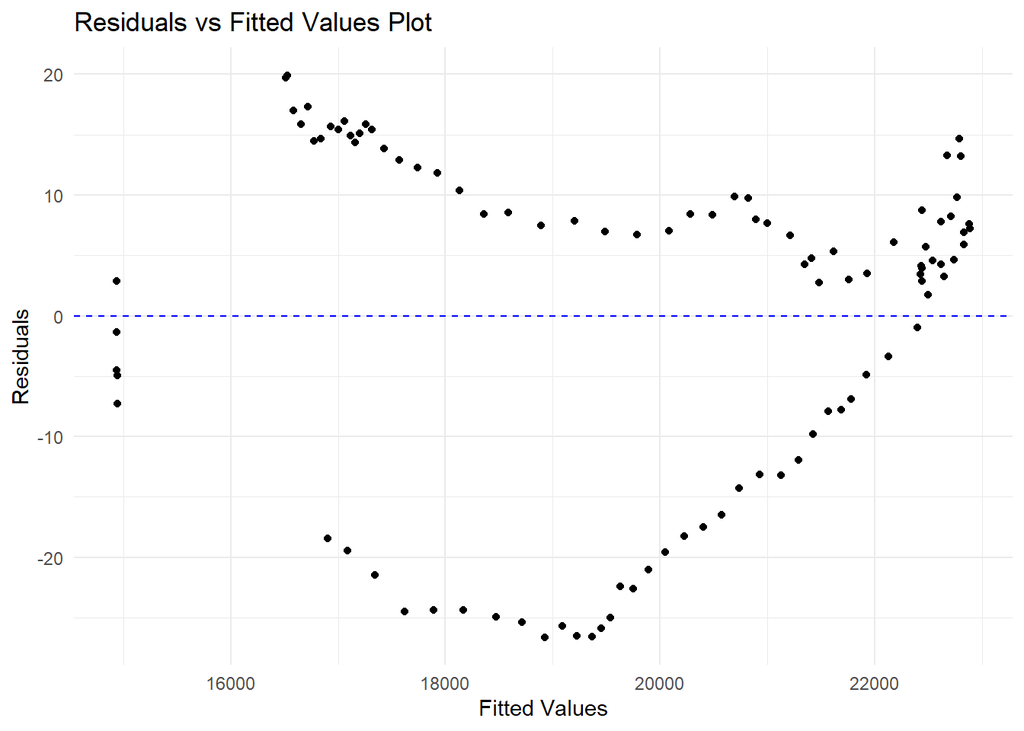

```r
#Plot residuals against fitted values to check for homoscedasticity
plot_resid_fitted <- ggplot() +
  geom_point(aes(x = fitted(fit), y = residuals)) +
  geom_hline(yintercept = 0, linetype = "dashed", color = "blue") +
  labs(x = "Fitted Values", y = "Residuals",
       title = "Residuals vs Fitted Values Plot") +
  theme_minimal()
print(plot_resid_fitted)
```

Q4.Prediction

```r
new_data <- data.frame(predict.lm(fit, data.frame(V = 10,n = 2,t = 0.2,tot_r = 1300, w = 0.25)))
new_data
```

```
##   predict.lm.fit..data.frame.V...10..n...2..t...0.2..tot_r...1300..
## 1                                                          25566.97
```

Here when random values are given to the independent variables Ship speed(V), Propeller rps(n), Total resistance (tot_r), Thrust deduction fraction (t) and wake fraction (w). the model predicted the dependent variable power would be 25566.97.

Q5.Model Accuracy

```r
#Make predictions using the model
predicted <- predict(fit, newdata = mydata)
```

```r
# Generate new data for prediction
new_data <- data.frame(V = 10, n = 2, t = 0.2, tot_r = 1300, w = 0.25)

# Make predictions
predicted_ship_data <- predict(fit, newdata = new_data)
print(predicted_ship_data)
```

```
##        1
## 25566.97
```

```r
# Model Accuracy
rsquared <- summary(fit)$r.squared
cat("R-squared:", rsquared, "\n")
```

```
## R-squared: 0.9999651
```

```r
adjusted_rsquared <- summary(fit)$adj.r.squared
cat("Adjusted R-squared:", adjusted_rsquared, "\n")
```

```
## Adjusted R-squared: 0.9999633
```

The high R-squared value of 0.9999651 and adjusted R-squared value of 0.9999633 suggest that the model explains almost all of the variability in the response variable, indicating an excellent fit to the data.

Visualizations plots:

```r
library(car)
```

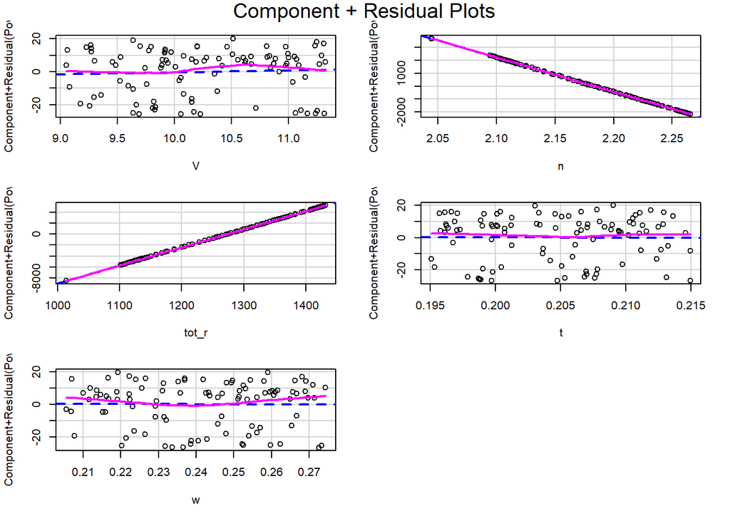

```r
#Nonlinearity
# component + residual plot
crPlots(fit)
```

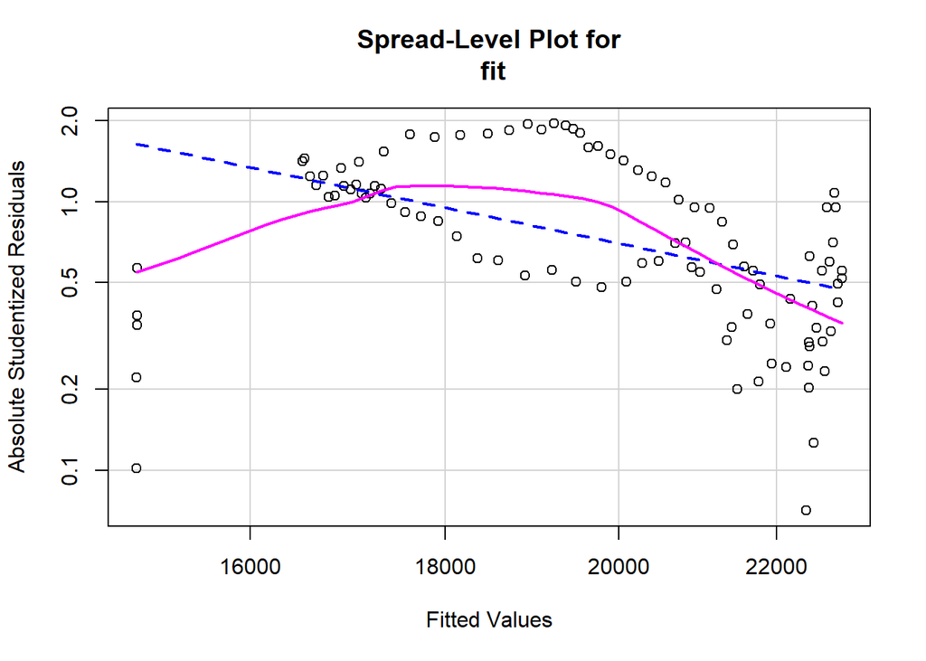

```
##
## Suggested power transformation:  3.922624
```

```r
# plot studentized residuals vs. fitted values
library(car)
spreadLevelPlot(fit)
```